# Explpre and Summarize Data by Abeer_Alfawzan

```
##     X fixed.acidity volatile.acidity citric.acid residual.sugar chlorides
## 1   1           7.4             0.70        0.00            1.9     0.076
## 2   2           7.8             0.88        0.00            2.6     0.098
## 3   3           7.8             0.76        0.04            2.3     0.092
## 4   4          11.2             0.28        0.56            1.9     0.075
## 5   5           7.4             0.70        0.00            1.9     0.076
## 6   6           7.4             0.66        0.00            1.8     0.075
## 7   7           7.9             0.60        0.06            1.6     0.069
## 8   8           7.3             0.65        0.00            1.2     0.065
## 9   9           7.8             0.58        0.02            2.0     0.073
## 10 10           7.5             0.50        0.36            6.1     0.071
##    free.sulfur.dioxide total.sulfur.dioxide density   pH sulphates alcohol
## 1                   11                   34  0.9978 3.51      0.56     9.4
## 2                   25                   67  0.9968 3.20      0.68     9.8
## 3                   15                   54  0.9970 3.26      0.65     9.8
```

[output cut: 18 more lines]

```
## 'data.frame':    1599 obs. of  13 variables:
##  $ X                   : int  1 2 3 4 5 6 7 8 9 10 ...
##  $ fixed.acidity       : num  7.4 7.8 7.8 11.2 7.4 7.4 7.9 7.3 7.8 7.5 ...
##  $ volatile.acidity    : num  0.7 0.88 0.76 0.28 0.7 0.66 0.6 0.65 0.58 0.5 ...
##  $ citric.acid         : num  0 0 0.04 0.56 0 0 0.06 0 0.02 0.36 ...
##  $ residual.sugar      : num  1.9 2.6 2.3 1.9 1.9 1.8 1.6 1.2 2 6.1 ...
##  $ chlorides           : num  0.076 0.098 0.092 0.075 0.076 0.075 0.069 0.065 0.073 0.071 ...
##  $ free.sulfur.dioxide : num  11 25 15 17 11 13 15 15 9 17 ...
##  $ total.sulfur.dioxide: num  34 67 54 60 34 40 59 21 18 102 ...
##  $ density             : num  0.998 0.997 0.997 0.998 0.998 ...
##  $ pH                  : num  3.51 3.2 3.26 3.16 3.51 3.51 3.3 3.39 3.36 3.35 ...
##  $ sulphates           : num  0.56 0.68 0.65 0.58 0.56 0.56 0.46 0.47 0.57 0.8 ...
##  $ alcohol             : num  9.4 9.8 9.8 9.8 9.4 9.4 9.4 10 9.5 10.5 ...
##  $ quality             : int  5 5 5 6 5 5 5 7 7 5 ...
```

# introduction:

Here is the dataset which i have choosed. it is about Red Wine quality.it contains 1,599 red wines with 13 variables on the chemical properties of the wine .

# Univariate Plots Section

Now will investigate the dataset .

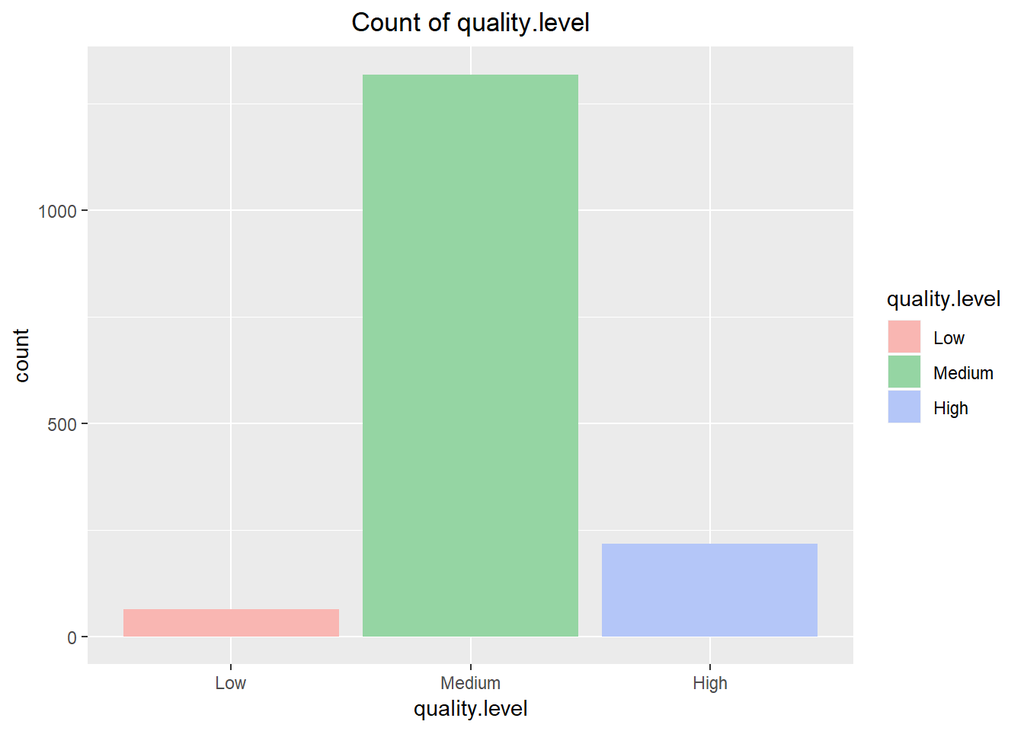

```
##    Low Medium   High
##     63   1319    217
```

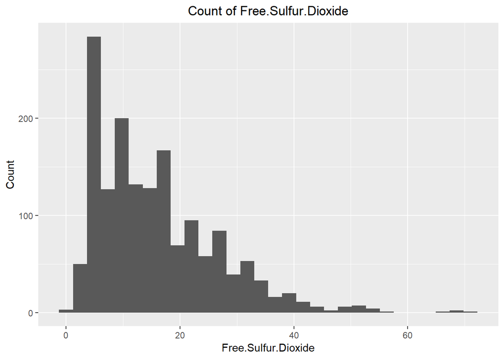

```
##    Min. 1st Qu.  Median    Mean 3rd Qu.    Max.
##    1.00    7.00   14.00   15.87   21.00   72.00
```

Here is the Histogram which define the distribution of free.sulfur.dioxide. it is clear from the graph the distribution is right skewed.

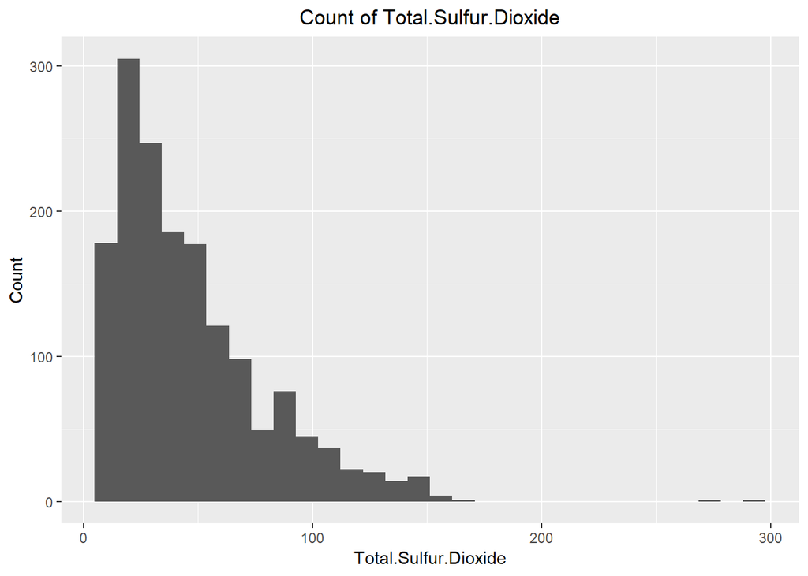

```
##    Min. 1st Qu.  Median    Mean 3rd Qu.    Max.
##    6.00   22.00   38.00   46.47   62.00  289.00
```

Here is the Histogram which define the distribution of total.sulfur.dioxide . it is clear from the graph the distribution is right skewed.

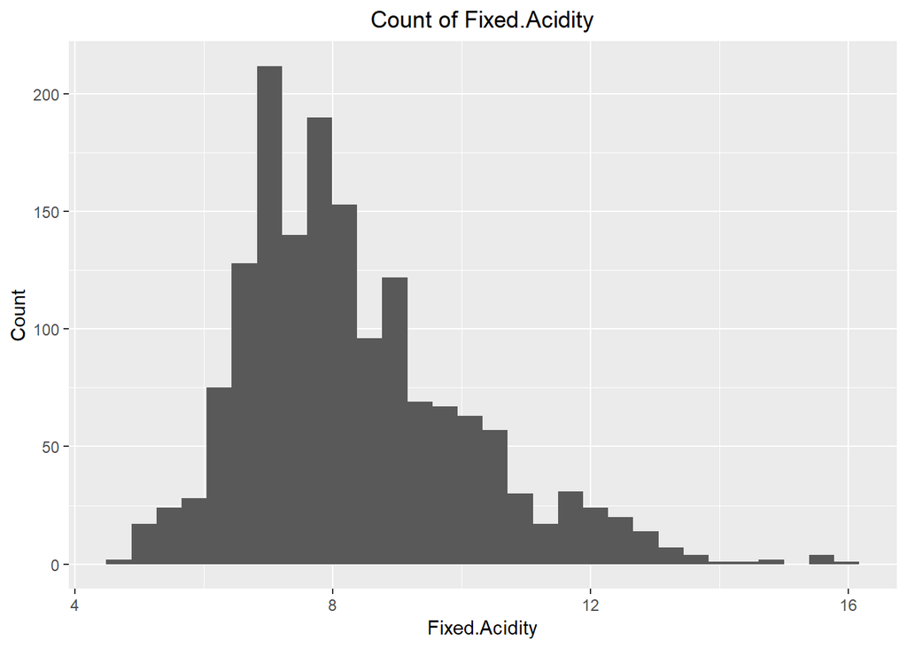

```
##    Min. 1st Qu.  Median    Mean 3rd Qu.    Max.
##    4.60    7.10    7.90    8.32    9.20   15.90
```

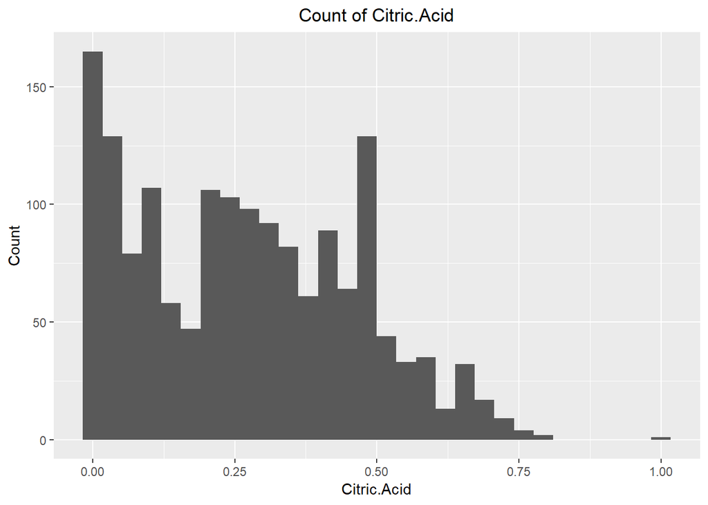

```
##    Min. 1st Qu.  Median    Mean 3rd Qu.    Max.
##   0.000   0.090   0.260   0.271   0.420   1.000
```

Here is the Histogram which define the distribution of citric.acid .it is clear from the graph the distribution is right skewed.we can see, citric.acid have 150 values that all were zero .

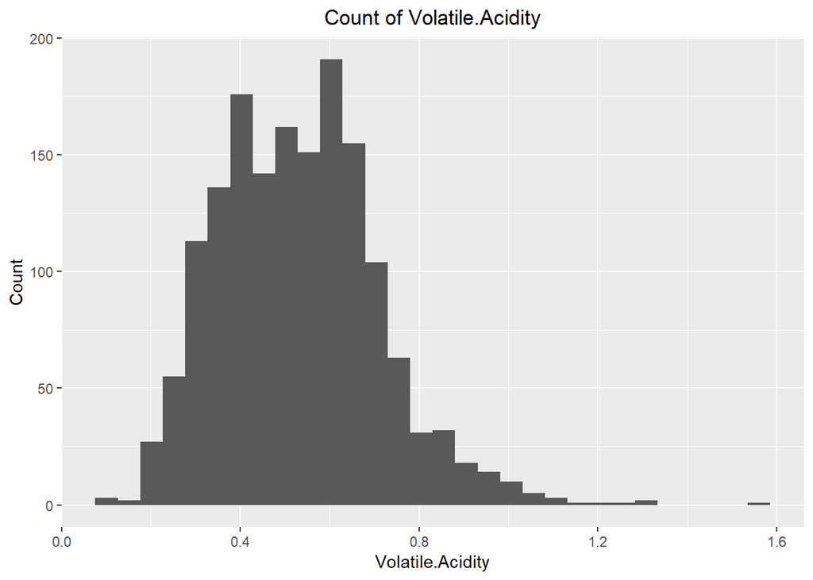

```
##    Min. 1st Qu.  Median    Mean 3rd Qu.    Max.
##  0.1200  0.3900  0.5200  0.5278  0.6400  1.5800
```

Here is the Histogram which defin the distribuation of volatile.acidity . it is clear from the graph the distribuation is looks normal distribuation .we can see, the highest volatile.acidity is arround .6 which have arround 190 values .

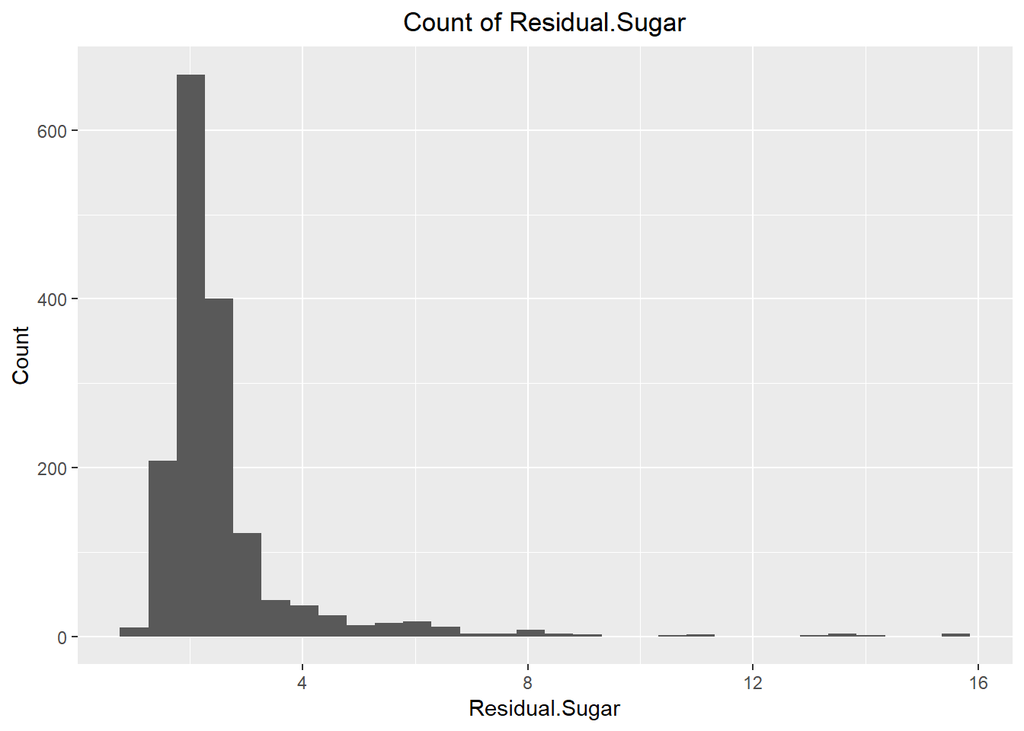

```
##    Min. 1st Qu.  Median    Mean 3rd Qu.    Max.
##   0.900   1.900   2.200   2.539   2.600  15.500
```

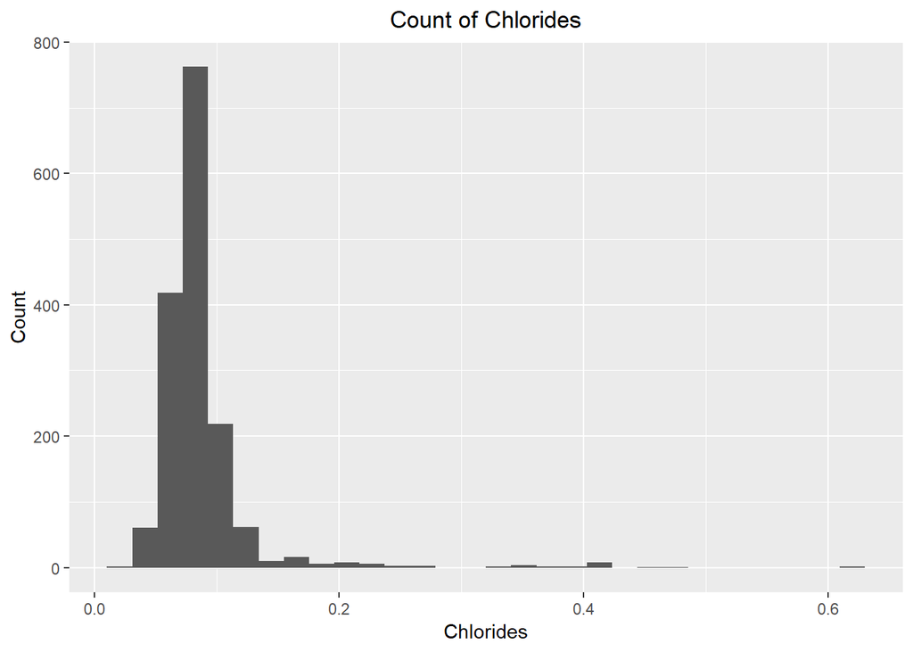

```
##    Min. 1st Qu.  Median    Mean 3rd Qu.    Max.
## 0.01200 0.07000 0.07900 0.08747 0.09000 0.61100
```

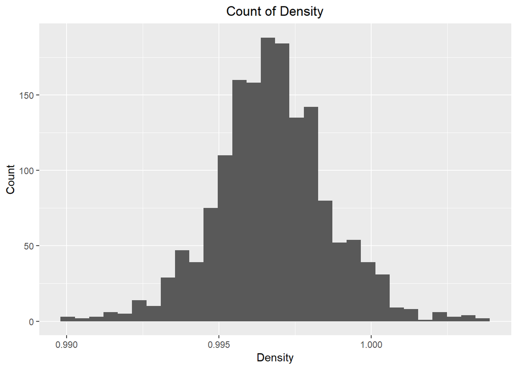

```
##    Min. 1st Qu.  Median    Mean 3rd Qu.    Max.
##  0.9901  0.9956  0.9968  0.9967  0.9978  1.0037
```

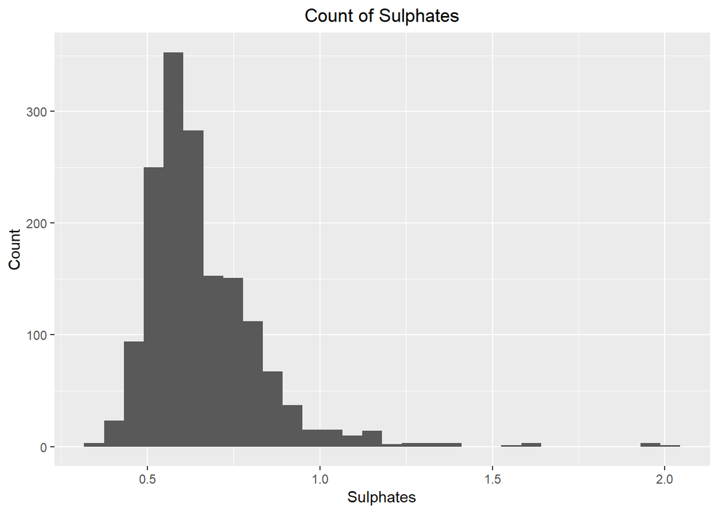

```
##    Min. 1st Qu.  Median    Mean 3rd Qu.    Max.
##  0.3300  0.5500  0.6200  0.6581  0.7300  2.0000
```

Here is the Histogram which defin the distribuation of sulphates .it is clear from the graph the distribuation is looks right skewed distribuation .we can define , the median of sulphates which is arround 0.6200 where is the mean which 0.6581.

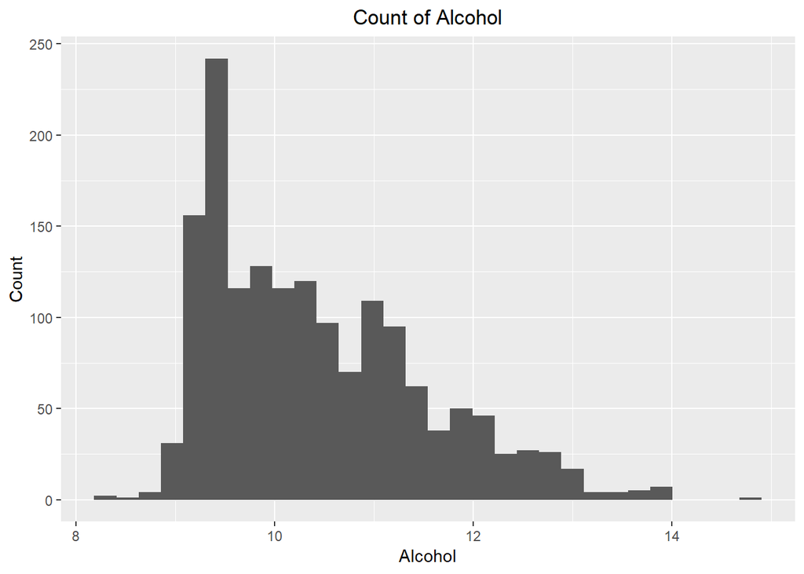

```
##    Min. 1st Qu.  Median    Mean 3rd Qu.    Max.
##    8.40    9.50   10.20   10.42   11.10   14.90
```

Here is the Histogram which define the distribution of alcohol .it is clear from the graph the distribution is looks right skewed distribution.we can define the highest value of alcohol which is around 9.25 .

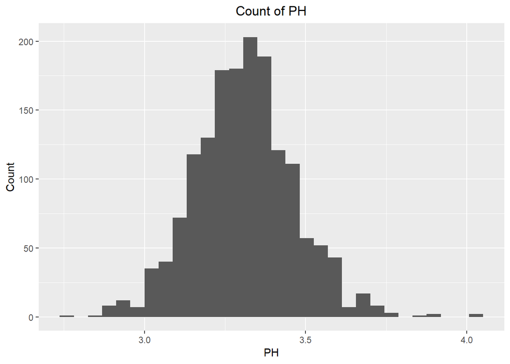

```
##    Min. 1st Qu.  Median    Mean 3rd Qu.    Max.
##   2.740   3.210   3.310   3.311   3.400   4.010
```

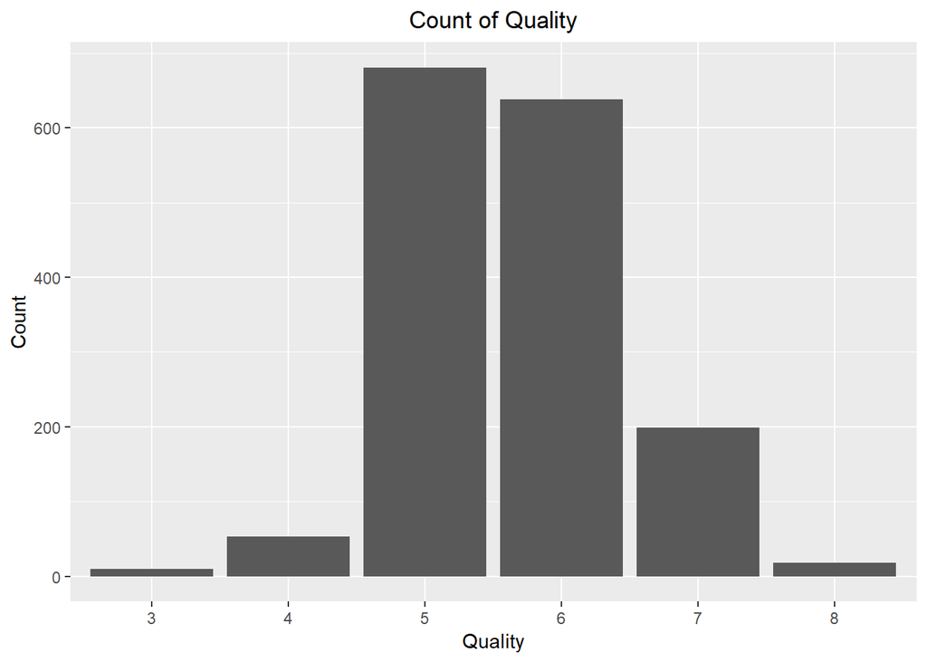

```
##   3   4   5   6   7   8
##  10  53 681 638 199  18
```

It is clear from the graph the distribution is looks normal distribution .we can find the highest level of quality is on 5 where the lowest level is on 3 .

# Univariate Analysis

### What is the structure of your dataset?

The dataset of Red Wine quality contains about 1,599 red wines with 14 variables on the chemical properties of the wine , include different features of Red Wine such as PH value,alchole,quality and sugar which wine contain.

### What other features in the dataset do you think will help support your investigation into your feature(s) of interest?

as the quality is the main feature in the data set,i think these variable (PH, residual sugar,density ,alcohol, fixed acidity and volatile acidity ) will affect in quality variable .

### Did you create any new variables from existing variables in the dataset?

yes , i have created new variable which called quality level which have 3 values: Low , Medium and high.

### Of the features you investigated, were there any unusual distributions? Did you perform any operations on the data to tidy, adjust, or change the form of the data? If so, why did you do this?

The dataset which i have choosed it was tidy, i dont need to clean or make any change on it .

# Bivariate Plots Section

In this section will create correlation matrix for all variables which help me to define the relationships between the variables based on the correlation between them.

```
##  [1] "X"                    "fixed.acidity"        "volatile.acidity"
##  [4] "citric.acid"          "residual.sugar"       "chlorides"
##  [7] "free.sulfur.dioxide"  "total.sulfur.dioxide" "density"
## [10] "pH"                   "sulphates"            "alcohol"
## [13] "quality"              "quality.level"
```

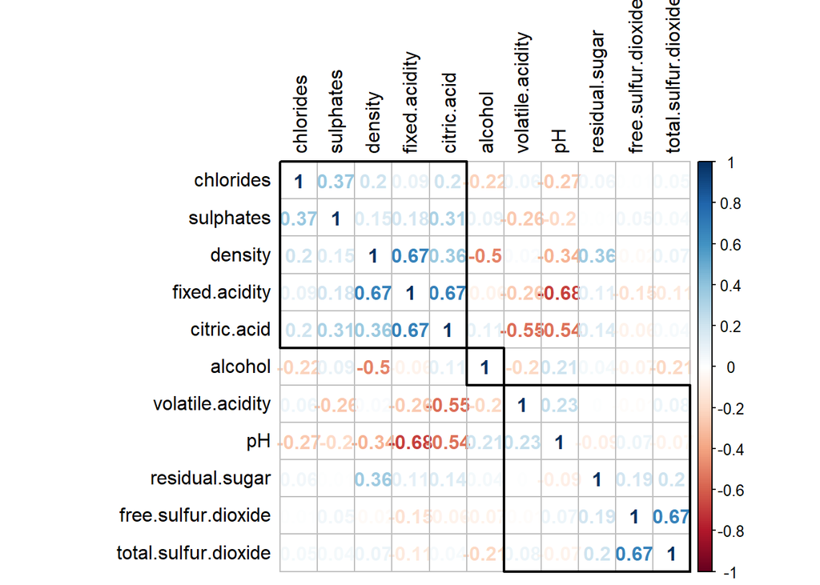

```
## 'data.frame':    1599 obs. of  13 variables:
##  $ fixed.acidity       : num  7.4 7.8 7.8 11.2 7.4 7.4 7.9 7.3 7.8 7.5 ...
##  $ volatile.acidity    : num  0.7 0.88 0.76 0.28 0.7 0.66 0.6 0.65 0.58 0.5 ...
##  $ citric.acid         : num  0 0 0.04 0.56 0 0 0.06 0 0.02 0.36 ...
##  $ residual.sugar      : num  1.9 2.6 2.3 1.9 1.9 1.8 1.6 1.2 2 6.1 ...
##  $ chlorides           : num  0.076 0.098 0.092 0.075 0.076 0.075 0.069 0.065 0.073 0.071 ...
##  $ free.sulfur.dioxide : num  11 25 15 17 11 13 15 15 9 17 ...
##  $ total.sulfur.dioxide: num  34 67 54 60 34 40 59 21 18 102 ...
##  $ density             : num  0.998 0.997 0.997 0.998 0.998 ...
##  $ pH                  : num  3.51 3.2 3.26 3.16 3.51 3.51 3.3 3.39 3.36 3.35 ...
##  $ sulphates           : num  0.56 0.68 0.65 0.58 0.56 0.56 0.46 0.47 0.57 0.8 ...
##  $ alcohol             : num  9.4 9.8 9.8 9.8 9.4 9.4 9.4 10 9.5 10.5 ...
##  $ quality             : Ord.factor w/ 6 levels "3"<"4"<"5"<"6"<..: 3 3 3 4 3 3 3 5 5 3 ...
##  $ quality.level       : Ord.factor w/ 3 levels "Low"<"Medium"<..: 2 2 2 2 2 2 2 3 3 2 ...
```

Here i have deleted the X variable which only indicate an index , so not nessesary to be avaialable in the dataset, also it is affect in correlation matrix for that i am deleting X variable . Correlation matrix has been created to defin the correlation and the relation between the variable .

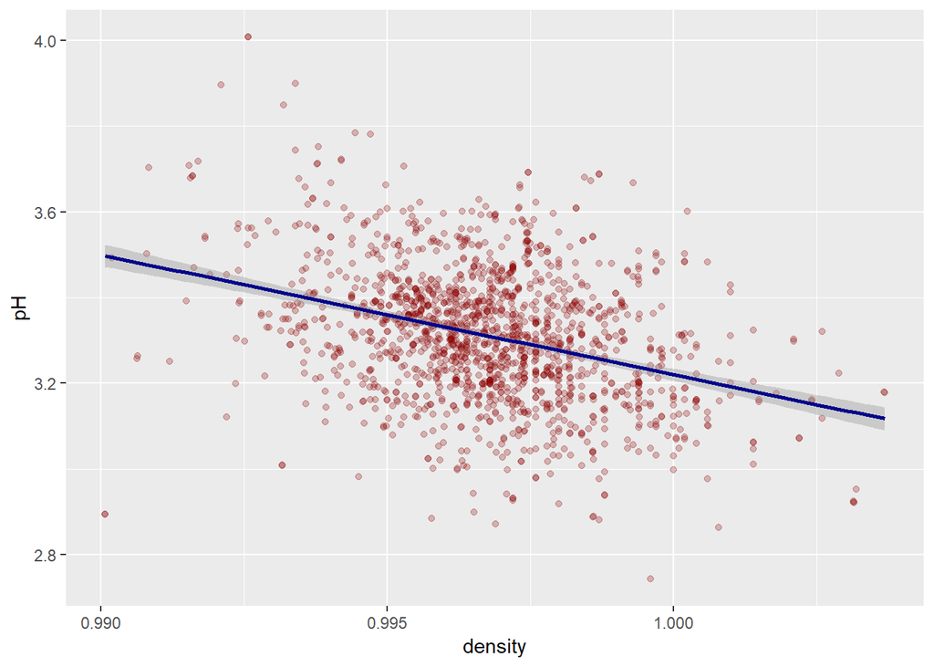

```
## [1] -0.3416993
```

It is clear from the graph , High pH having low concentration of density. also, we can see the much concentration of density is between .995 and .997 on PH between 3.2 and 3.6 . The correlation between these variable is negative , which mean PH increase as the other variable decreases.

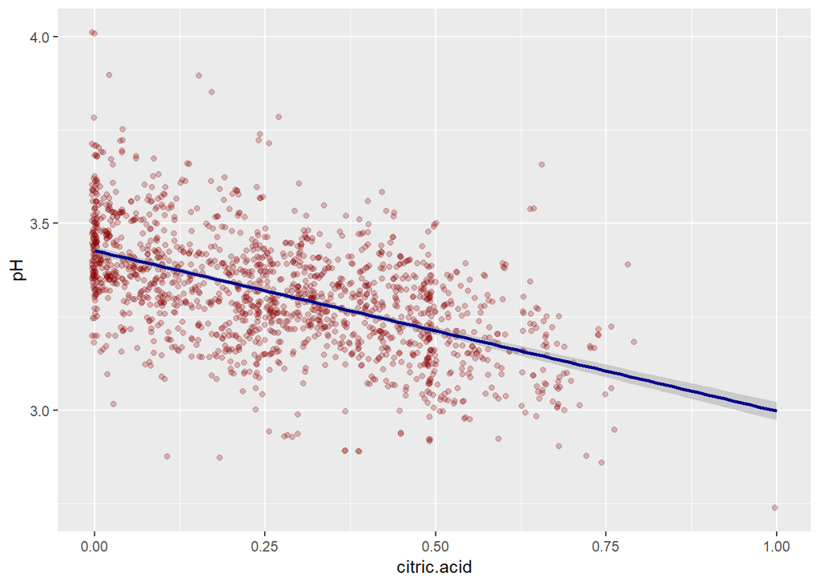

```
## [1] -0.5419041
```

Here we can see , High pH having low concentration of citric.acid . also,it is clear fron the grap the much concentration of citric.acid is between 0.00 and 0.50 on PH between 3.2 and 3.6 . The correlation between these variable is negative which mean when PH increase then citric.acid decrease .

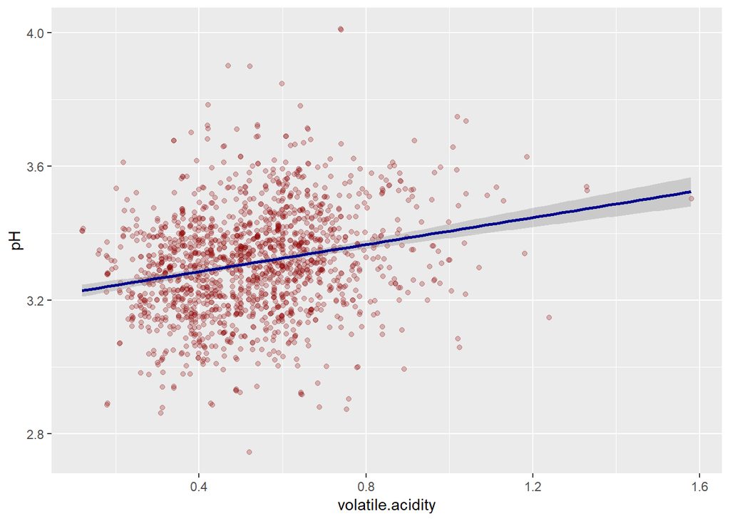

```
## [1] 0.2349373
```

Here we can see , High pH having high concentration of volatile.acidity. also, we can define the much concentration of volatile.acidity is between 0.3 and 0.7 on PH between 3.0 and 3.5 . The correlation between these variable is positive which mean PH increase as volatile.acidity increase .

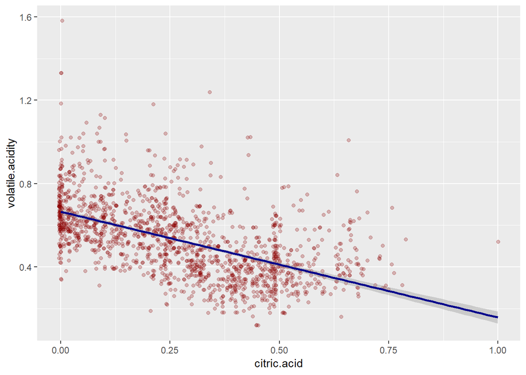

```
## [1] -0.5524957
```

Here It seems that for wines with volatile.acidity , having a less concentration of citric.acid . the correlation here between the variables is negative .

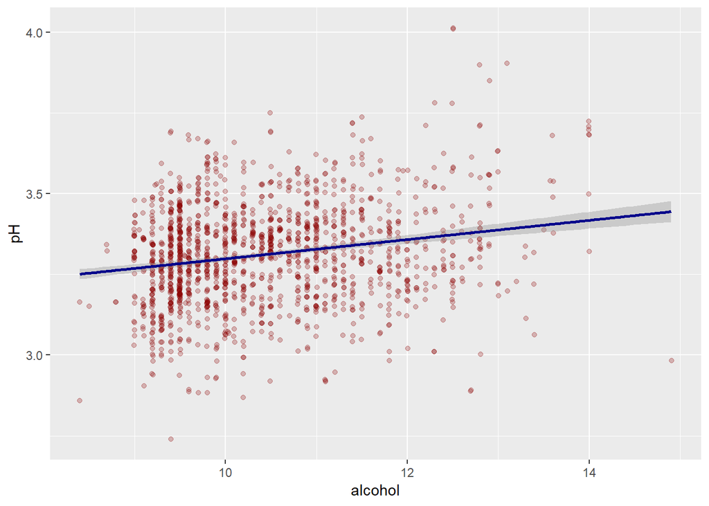

```
## [1] 0.2056325
```

Here It seems that for wines with high alcohol content, having a high concentration of PH .the correlation between these variables is positive.

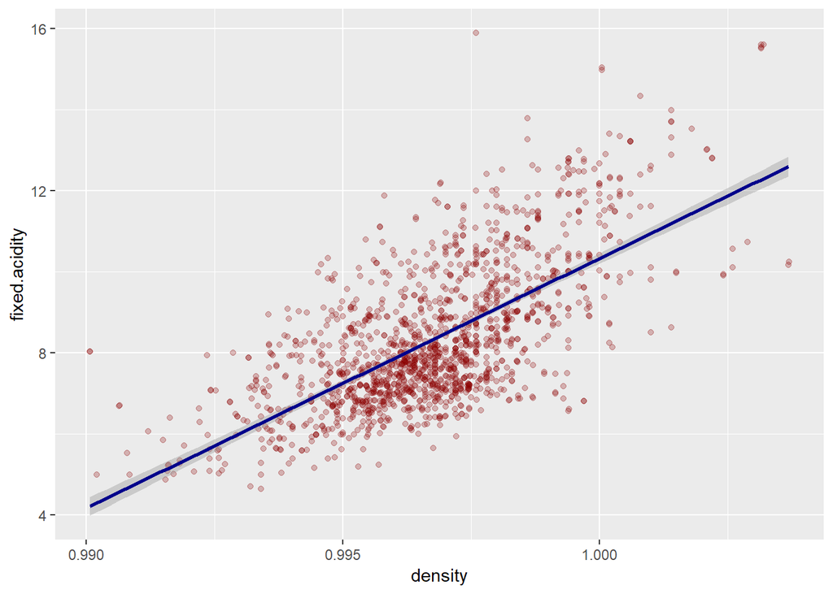

```
## [1] 0.6680473
```

Here It seems that for wines with high density , having a high concentration of fixed.acidity . The correlation between these variable is positive.

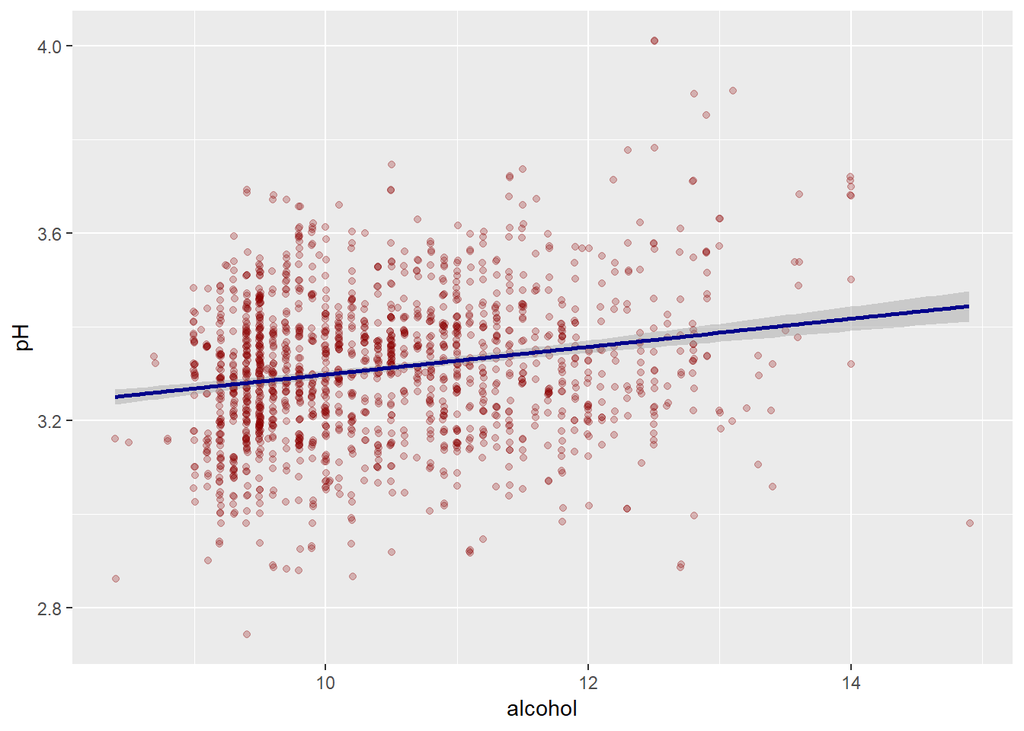

```
## [1] 0.2056325
```

Here It seems that for wines with high PH , having a high concentration of alcohol . The correlation between these variable is positive.

# Bivariate Analysis

### Talk about some of the relationships you observed in this part of the investigation. How did the feature(s) of interest vary with other features in the dataset?

once i created the correlation matrix ,i defined the correlation between the variable weather is negative or positive. based on the Analysis i defin the relationships between the variable as follow: the negative correlation is between density,pH /citric.acid,volatile.acidity /citric.acid,PH. while the positive correlation is between density, fixed.acidity/alcohoh,ph/volatile.acidity,PH.

### Did you observe any interesting relationships between the other features (not the main feature(s) of interest)?

I observed a strong correlation between density,fixed.acidity of wine they had positive relationship, indicating that wines with more density have more residual fixed.acidity. I also found the strong negative correlation between citric.acid, volatile.acidity .the more citric.acid of wine , contains the lower of volatile.acidity .

# Multivariate Plots Section

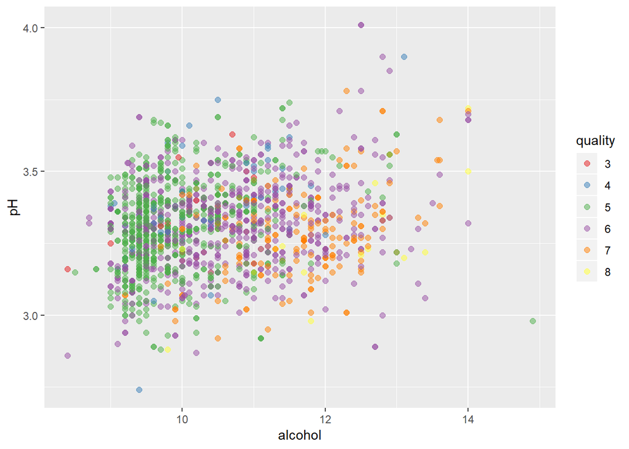

It is clear from the graph , when the value of alcohol between 9 and 10 while the value of PH between 3.0 and 3.5 lead to medium quality .the relationship between PH and alcohol is positive rerationship .

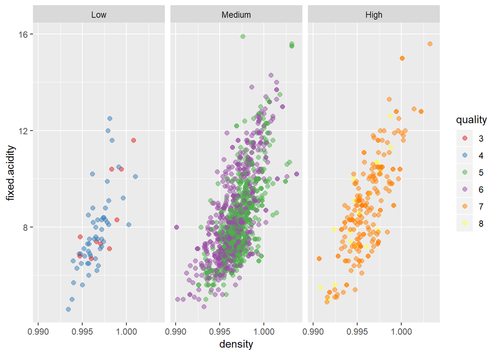

Here we are trying to defin the relationship between 3 variables . we can see from the visulaizattion, most value of density which is on level medium and high .The relationship between density and fixed.acidity is positive rerationship .

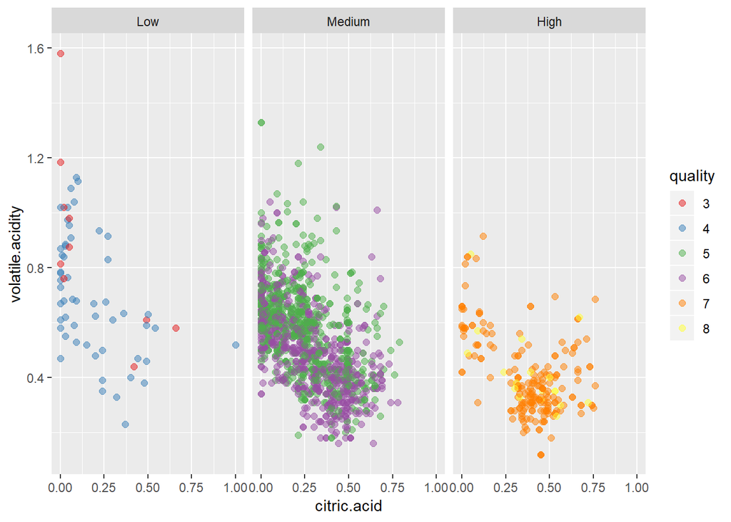

Here we are trying to defin the relationship between 3 variables . we can see from the visulaizattion, most value of citric.acid which is on level medium and high while the least values on level low.The correlation here between these variables is negative .

# Multivariate Analysis

### Talk about some of the relationships you observed in this part of the investigation. Were there features that strengthened each other in terms of looking at your feature(s) of interest?

I have created scatterplot to investigate the interactions between PH, alcohol ,colred by qyality .the relationships between these variable was positive relationships. the value of alcohol which between 9 and 10 while the value of PH which between 3.0 and 3.5 lead to medium quality .

### Were there any interesting or surprising interactions between features?

The intersting bart here: choosing the scaterplot colored by quality to define the relationship between these 3 variables, if the PH increased then alcohol increased .

### OPTIONAL: Did you create any models with your dataset? Discuss the strengths and limitations of your model.

# Final Plots and Summary

### Plot One

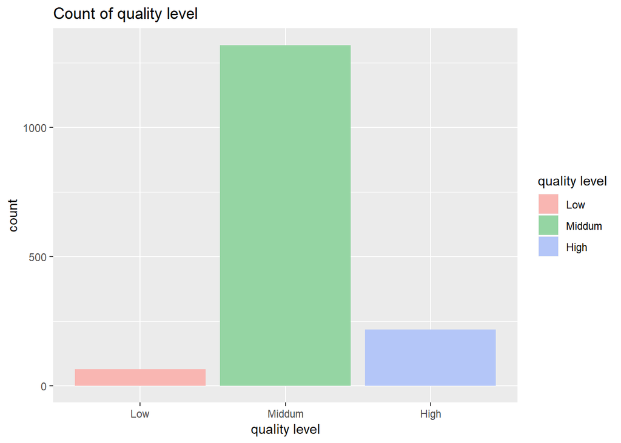

```
##    Low Middum   High
##     63   1319    217
```

### Plot Two

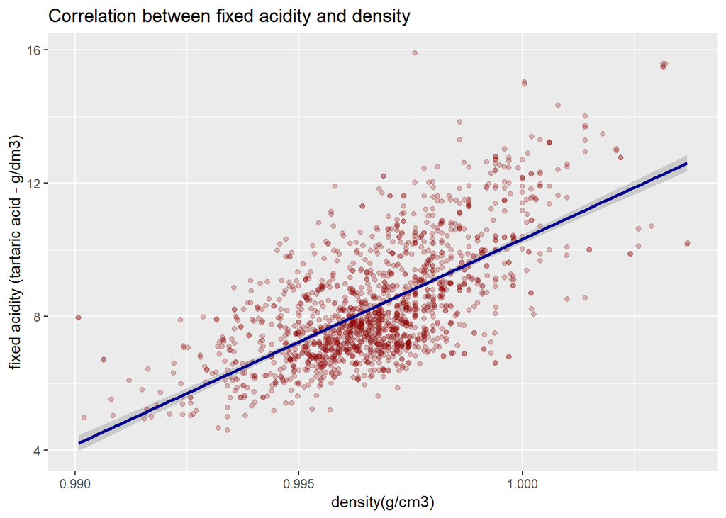

```
## [1] 0.6680473
```

### Description Two

Here It seems that for wines with high density , having a high concentration of fixed.acidity . The correlation between these variable is positive which mean : when fixed.acidity increased density increased .

### Plot Three

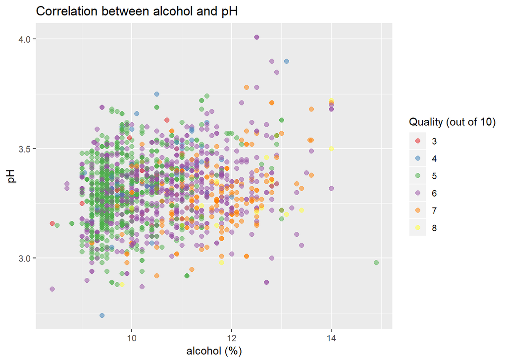

### Description Three

It is clear from the graph , when the value of alcohol between 9 and 10 while the value of PH between 3.0 and 3.5 lead to medium quality .the relationship between PH and alcohol is positive rerationship . ——

# Reflection

In this project and throught the analysis , i found the quality consider the most featsure in the dataset. there are many varible which affect on quality of wine such as (PH, residual sugar,density ,alcohol, fixed acidity and volatile acidity ) , these varibles will cause better or bad wine . for example, when the value of alcohol between 9 and 10 while the value of PH between 3.0 and 3.5 lead to medium quality. Also, wines with high PH , having a high concentration of alcohol. the question that i want to add : why there is no column related to the taste of wine based on country , because Swedish persons, their taste is different from the English and different from the American people .